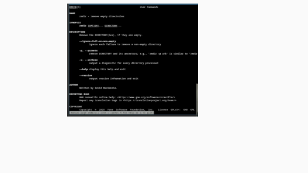

Рисунок 20: man rmdir(-p удаляет так же родительский каталоги, если они

становятся пустями -v- выводит сообщение о каждом удалённом каталоге)

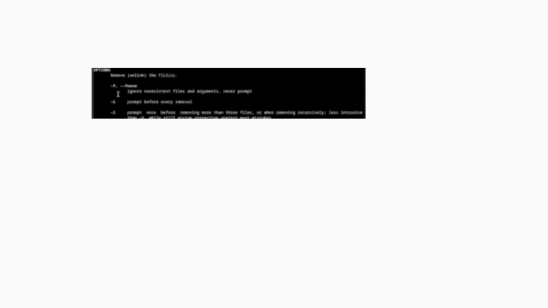

Рисунок 21: man rm(-r-рекурсивное удаление(для каталогов с содержанием) -i-

запрашивает подтверждение перед удалением -f- принудительное удаление без

запросов и игнорирования несущ.файлов)

Используя информацию, полученную при помощи команды history,

выполняем модификацию и исполнение нескольких команд из буфера

команд.

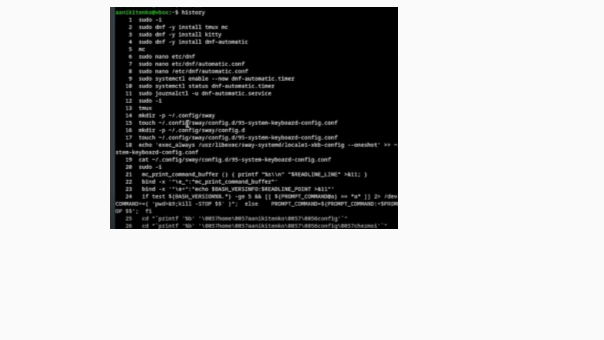

Рисунок 22: Просмотр истории команд-history

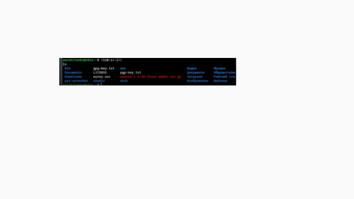

[figure not shown]

Выводы

[figure not shown]

Контрольные вопросы

1.Командная строка — это интерфейс взаимодействия пользователя с

операционной системой, при котором команды вводятся в виде текстовых

строк. Пользователь вводит команды с клавиатуры, и система их

выполняет. В Unix-подобных системах командная строка реализуется

через командные интерпретаторы (shell), такие как /bin/sh, /bin/bash,

/bin/csh, /bin/ksh.

2.Для определения абсолютного пути текущего каталога используется

команда pwd (print working directory).(Пример: pwd Результат:

/home/aanikitenko/documents)

3.Для определения типа файлов и их имён используется команда ls с

опцией -F (или –classify). Эта опция добавляет к именам файлов символы,

обозначающие тип: / для каталогов, * для исполняемых файлов, @ для

символических ссылок.(Пример ls -F Результат Documents/ script.sh* file.txt

)

6.Для вывода списка ранее выполненных команд используется команда

history. Пример: history Результат: 1 pwd2 cd /tmp 3 ls -la 4. cd ~ 5 mkdir

newdir

7.Для модифицированного выполнения команд из истории используется

8.Для последовательного выполнения нескольких команд в одной строке

используется символ ; (точка с запятой).

Примеры: cd; ls pwd; ls -la; cd /tmp

9.Экранирование — это способ использования специальных символов как

обычных, без их специального значения. В командной строке для

экранирования используется обратный слеш .

Пример touch файл с пробелами.txt (создание файла с пробелом)

10.Команда ls -l выводит подробную информацию о файлах и каталогах в

следующем формате: тип файла, права доступа, количество ссылок,

владелец, группа, размер в байтах, дата и время последнего изменения,

имя файла или каталога.

Пример: -rw-r–r– 1 user group 1024 Apr 15 10:30 file.txt

11.Относительный путь — это путь относительно текущего каталога. Он не

начинается с / и использует обозначения: . для текущего каталога и .. для

родительского каталога.

Абсолютный путь — это полный путь от корневого каталога (/) до файла

или каталога, который всегда начинается с /.

12.Для получения информации о команде используется команда man

клавиши: Space (страница вперёд), Enter (строка вперёд), q (выход).

Примеры:man ls man cd

13.Для автоматического дополнения вводимых команд используется

клавиша Tab (табуляция). При вводе начала имени команды или файла

нажатие Tab автоматически дополняет имя, если оно однозначно

определено. Если есть несколько вариантов, повторное нажатие Tab

показывает все возможные варианты. Пример: cd /hom + Tab → cd /home/